# Multiple Testing

FDR Control

Last update: 2026-02-01

In this section, we introduce an example of the multiple testing problem and the FDR control method.

# 1 Setting constants and parameters

First, we set the constants for the simulation. `N` is the sample size, `M` is the number of null hypotheses, `M_0` is the number of true null hypotheses, `L` is the number of simulations, and `alpha` is the significance level.`

```r
set.seed(1)
N <- 500
M <- 60
M_0 <- 45
L <- 100
alpha <- 0.05
tau_population <- 0.2
```

# 2 Failure to control the type I error

## 2.1 Generating data

We first fix the seed and generate samples from a randomized experiment. We generate a treatment assignment variable from a uniform random number, multiply it by the average treatment effect `tau_population`, and add independent standard normal distributions to make the observed outcomes. However, at this time, the first 15 latent results have a treatment effect, and the remaining 45 latent results do not have a treatment effect.

```r
z <-
  (
    runif(N) >= 0.5
  )
df_list_1 <-
  seq_len(M - M_0) %>%
  purrr::map(
    ~ tibble::tibble(
        z = z,
        y = rnorm(N) + tau_population * z
      )
  )
df_list_0 <-
  seq_len(M_0) %>%
  purrr::map(
    ~ tibble::tibble(
        z = z,
        y = rnorm(N)
      )
  )
df_list <-
  c(
    df_list_1,
    df_list_0
  )
```

## 2.2 Hypothesis testing

We perform 60 independent linear regressions to test each null hypothesis. We then calculate the t-value and p-value of the regression coefficient.

```r
result_list_1 <-
  df_list_1 %>%
  purrr::map(
    ~ lm(
        formula = y ~ z,
        data = .
      )
  )
result_list_0 <-
  df_list_0 %>%
  purrr::map(
    ~ lm(
        formula = y ~ z,
        data = .
      )
  )
```

```r
t_list_1 <-
  result_list_1 %>%
  purrr::map(
    ~ summary(.) %>%
      coef() %>%
      .[
        "zTRUE",
        "t value"
      ]
  ) %>%
  purrr::reduce(c)
t_list_0 <-
  result_list_0 %>%
  purrr::map(
    ~ summary(.) %>%
      coef() %>%
      .[
        "zTRUE",
        "t value"
      ]
  ) %>%
  purrr::reduce(c)
```

```r
p_list_1 <-
  result_list_1 %>%
  purrr::map(
    ~ summary(.) %>%
      coef() %>%
      .[
        "zTRUE",
        "Pr(>|t|)"
      ]
  ) %>%
  purrr::reduce(c)
p_list_0 <-
  result_list_0 %>%
  purrr::map(
    ~ summary(.) %>%
      coef() %>%
      .[
        "zTRUE",
        "Pr(>|t|)"
      ]
  ) %>%
  purrr::reduce(c)
```

## 2.3 FDR

We plot the absolute values of the test statistics of the 15 null hypotheses that are false in ascending order. We also show the rejection region corresponding to the significance level 0.05.

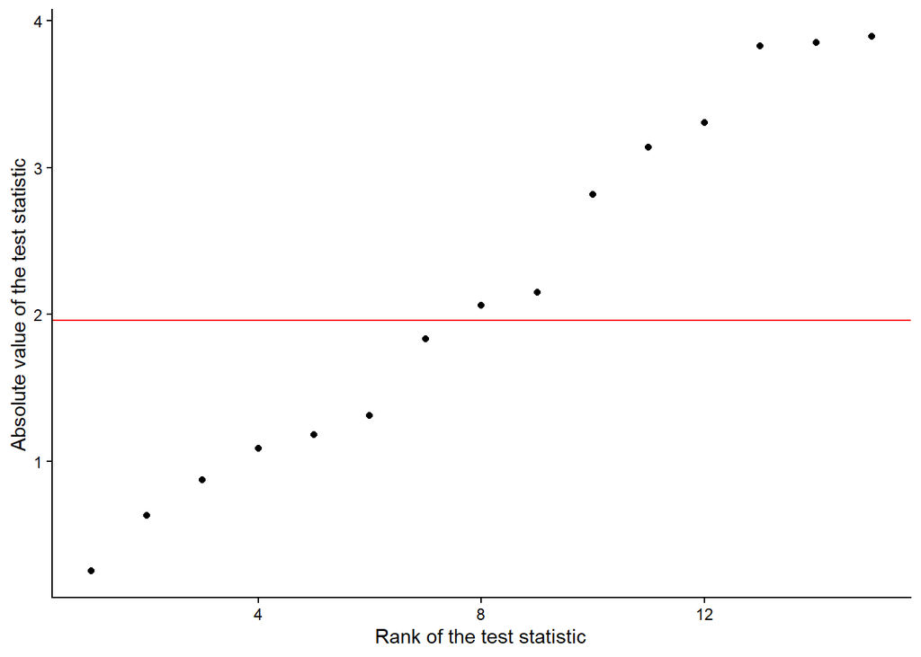

```r
ggplot(
  mapping =
    aes(
        x = seq_along(t_list_1),
        y = t_list_1 %>% abs() %>% sort()
    )
  ) +
  geom_point() +
  geom_hline(
    yintercept = abs(
      qnorm(
        1 - alpha / 2
      )
    ),
    color = "red"
  ) +
  labs(
    x = "Rank of the test statistic",
    y = "Absolute value of the test statistic"
  ) +
  theme_classic()
```

We also plot the p-values in the same way, and the result is as follows.

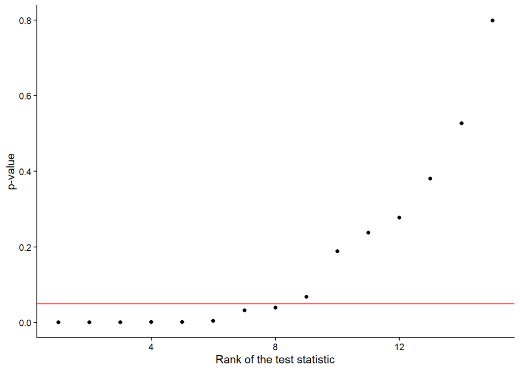

```r
ggplot(
  mapping =
    aes(
        x = seq_along(p_list_1),
        y = p_list_1 %>% sort()
    )
  ) +
  geom_point() +
  geom_hline(
    yintercept = alpha,
    color = "red"
  ) +
  labs(
    x = "Rank of the test statistic",
    y = "p-value"
  ) +
  theme_classic()
```

Next, we plot the absolute values of the test statistics of the 45 null hypotheses that are true in ascending order. We also show the rejection region corresponding to the significance level 0.05.

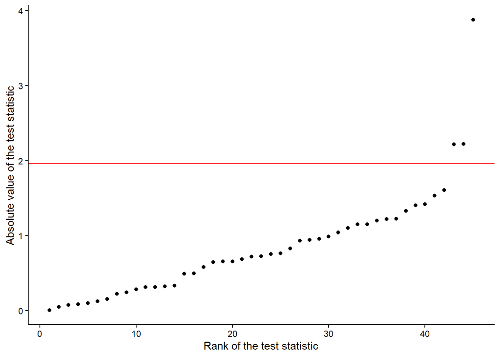

```r
ggplot(
  mapping =
    aes(
        x = seq_along(t_list_0),
        y = t_list_0 %>% abs() %>% sort()
    )
  ) +
  geom_point() +
  geom_hline(
    yintercept = abs(
      qnorm(
        1 - alpha / 2
      )
    ),
    color = "red"
  ) +
  labs(
    x = "Rank of the test statistic",
    y = "Absolute value of the test statistic"
  ) +
  theme_classic()
```

We also plot the p-values in the same way, and the result is as follows.

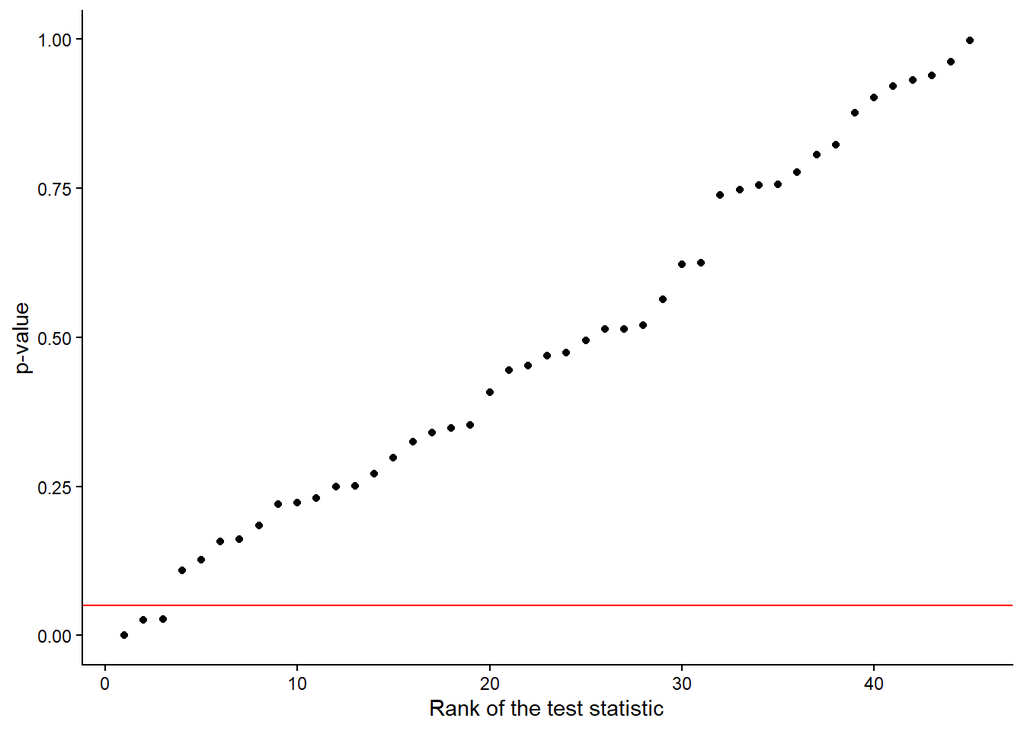

```r
ggplot(
  mapping =
    aes(
        x = seq_along(p_list_0),
        y = p_list_0 %>% sort()
    )
  ) +
  geom_point() +
  geom_hline(
    yintercept = alpha,
    color = "red"
  ) +
  labs(
    x = "Rank of the test statistic",
    y = "p-value"
  ) +
  theme_classic()
```

We list the test statistics of the null hypotheses that are correctly rejectegd among the 15 null hypotheses.

```r
t_list_rejected_1 <-
  t_list_1[
    t_list_1 %>% abs() >
    abs(qnorm(1 - alpha / 2))
  ]
t_list_rejected_1
```

```
## [1] 3.824994 2.815632 3.848504 2.061319 2.152388 3.306946 3.137302 3.890358
```

On the other hand, we list the test statistics of the null hypotheses that are incorrectly rejected among the 45 null hypotheses.

```r
t_list_rejected_0 <-
  t_list_0[
    t_list_0 %>% abs() >
    abs(qnorm(1 - alpha / 2))
  ]
t_list_rejected_0
```

```
## [1] -3.875394 -2.214476 -2.222917
```

The FDR is the proportion of null hypotheses that are incorrectly rejected among the rejected null hypotheses. Specifically, it is calculated as follows.

```r
fdr <-
  t_list_rejected_0 %>% length() / (
    t_list_rejected_1 %>% length() +
    t_list_rejected_0 %>% length()
  )
fdr
```

```
## [1] 0.2727273
```

# 3 FDR control

Now let’s apply the method to control the FDR.

## 3.1 Benjamini-Hochberg correction

The Benjamini-Hochberg method orders the p-values in ascending order as $p^{(1)}, \cdots, p^{(M)}$, and then starts from $l = M$, and if $p^{(l)}$ is less than $\alpha l/M$, all tests with p-values smaller than $p^{(l)}$ are rejected.

```r
p_list_sorted <-
  c(
    p_list_1,
    p_list_0
  ) %>%
  sort()
i <- M
flag_continue <- TRUE
while (
  flag_continue & i > 1
) {
  test <- p_list_sorted[i] <= (i / M) * alpha
  if (
    test
  ) {
    flag_continue <- FALSE
  }
  i <- i - 1
}
```

The number of rejected null hypotheses and the p-value threshold are as follows.

```r
i
```

```
## [1] 6
```

```r
p_list_sorted[i]
```

```
## [1] 0.00180606
```

The test statistics of the null hypotheses that are correctly rejected among the 15 false null hypotheses are those with p-values less than the threshold.

```r
p_list_rejected_benjamini_hochberg_1 <-
  p_list_1[
    p_list_1 <= p_list_sorted[i]
  ]
p_list_rejected_benjamini_hochberg_1
```

```
## [1] 0.0001473831 0.0001343046 0.0010113291 0.0018060602 0.0001136919
```

The test statistics of the null hypotheses that are incorrectly rejected among the 45 true null hypotheses are those with p-values less than the threshold.

```r
p_list_rejected_benjamini_hochberg_0 <-
  p_list_0[
    p_list_0 <= p_list_sorted[i]
  ]
p_list_rejected_benjamini_hochberg_0
```

```
## [1] 0.0001206915
```

Therefore, the FDR is as follows.

```r
fdr_benjamini_hochberg <-
  p_list_rejected_benjamini_hochberg_0 %>% length() / (
    p_list_rejected_benjamini_hochberg_1 %>% length() +
    p_list_rejected_benjamini_hochberg_0 %>% length()
  )
fdr_benjamini_hochberg
```

```
## [1] 0.1666667
```

The FDR was 0.2727273 earlier, but the FDR by the Benjamini-Hochberg method is 0.1666667, which is slightly lower.

To confirm this, we will write the function for the data generation process, perform 100 simulations, and calculate the expected value of the FDR.

```r
p_list_all <-
  seq_len(L) %>%
  purrr::map(
    ~ compute_p_value_mixed_effect(
        N = N,
        M = M,
        M_0 = M_0,
        tau_population = tau_population,
        seed = .
      )
  )
```

Moreover, we will write the function to calculate the p-value threshold by the Benjamini-Hochberg method and apply it to the simulation results.

```r
p_value_all <-
  p_list_all %>%
  purrr::map(
    ~ compute_p_value_benjamini_hochberg(
        p_list_1 = .$p_list_1,
        p_list_0 = .$p_list_0,
        alpha = alpha
      )
  )
```

We will also write the function to calculate the FDR and apply it to the simulation results.

```r
fdr_expected <-
 purrr::map2(
    p_list_all,
    p_value_all,
    ~ compute_fdr(
        p_list_1 = .x$p_list_1,
        p_list_0 = .x$p_list_0,
        p_value = .y
    )
 ) %>%
 purrr::reduce(c) %>%
 mean()

fdr_expected
```

```
## [1] 0.02511652
```

In this way, we can see that the expected FDR is controlled to a value smaller than 0.0251165 and 0.05.

## 3.2 Benjamini-Yekutieli correction

The Benjamini-Hotchberg correction above has been theoretically shown to control the FDR to some extent when the tests are independent or when there is a certain positive correlation (Positive Regression Dependence), but it cannot control the FDR for general correlations. On the other hand, the following Benjamini-Yakutieli method has been shown to control the FDR for any correlation.

```r
p_list_sorted <-
  c(
    p_list_1,
    p_list_0
  ) %>%
  sort()
i <- M
flag_continue <- TRUE
while (
  flag_continue & i > 1
) {
  test <-
    (
      p_list_sorted[i] <= (i / M) * alpha / sum(1 / seq_len(M))
    )
  if (
    test
  ) {
    flag_continue <- FALSE
  }
  i <- i - 1
}
```

The number of rejected null hypotheses and the p-value threshold are as follows.

```r
i
```

```
## [1] 3
```

```r
p_list_sorted[i]
```

```
## [1] 0.0001343046
```

The test statistics of the null hypotheses that are correctly rejected among the 15 false null hypotheses are those with p-values less than the threshold.

```r
p_list_rejected_benjamini_yekutieli_1 <-
  p_list_1[
    p_list_1 <= p_list_sorted[i]
  ]
p_list_rejected_benjamini_yekutieli_1
```

```
## [1] 0.0001343046 0.0001136919
```

The test statistics of the null hypotheses that are incorrectly rejected among the 45 true null hypotheses are those with p-values less than the threshold.

```r
p_list_rejected_benjamini_yekutieli_0 <-
  p_list_0[
    p_list_0 <= p_list_sorted[i]
  ]
p_list_rejected_benjamini_yekutieli_0
```

```
## [1] 0.0001206915
```

Therefore, the FDR is as follows.

```r
fdr_benjamini_yekutieli <-
  p_list_rejected_benjamini_yekutieli_0 %>% length() / (
    p_list_rejected_benjamini_yekutieli_1 %>% length() +
    p_list_rejected_benjamini_yekutieli_0 %>% length()
  )
fdr_benjamini_yekutieli
```

```
## [1] 0.3333333
```

When we apply it to the simulation data of 100 times and calculate the expected FDR, we get the following.

```r
p_value_all <-
  p_list_all %>%
  purrr::map(
    ~ compute_p_value_benjamini_yekutieli(
        p_list_1 = .$p_list_1,
        p_list_0 = .$p_list_0,
        alpha = alpha
      )
  )
```

```r
fdr_expected <-
 purrr::map2(
    p_list_all,
    p_value_all,
    ~ compute_fdr(
        p_list_1 = .x$p_list_1,
        p_list_0 = .x$p_list_0,
        p_value = .y
    )
 ) %>%
 purrr::reduce(c) %>%
 mean()

fdr_expected
```

```
## [1] 0.002
```

Thus, the rejection probability becomes smaller than 0.05, but is too conservative.